# Distribución de los datos

Osmar Dominique

2025-08-20

Una manera de analizar los datos es mediante tablas de frecuencias. Se tienen 4 tipos de frecuencias:

- Frecuencias absolutas: cuántas se tienen de un mismo valor.
- Frecuencias relativas: proporción o porcentaje de la frecuencia absoluta.
- Frecuencias acumuladas (absolutas o relativas): suma acumulada de las frecuencias absolutas o relativas de los datos.

Al obtener una tabla con los valores de los datos y las 4 frecuencias se obtiene una **tabla de estadística** o **tabla de frecuencias**.

## Ejemplo:

Vamos a generar 30 datos que tomen los valores 5,7,8,9. (datos cuantitativos discretos)

```
##  [1] 8 8 8 7 8 7 7 7 8 5 9 7 7 5 7 8 9 5 8 8 5 9 5 5 5 8 9 7 8 7
```

La tabla estadística de nuestros datos es:

```
##   calificaciones f_absoluta f_relativa fa_acumulada fr_acumulada
## 1              5          7       0.23            7         0.23
## 2              7          9       0.30           16         0.53
## 3              8         10       0.33           26         0.87
## 4              9          4       0.13           30         1.00
```

## Ejercicio:

Vamos a generar 100 datos que tomen las calificaciones 5,6,7,8,9,10. (datos cuantitativos discretos)

```
##   [1]  7 10  7  6  6 10  7  9  8 10 10  5  6  7  9  7  7  5  8  5  5  9  7  6  6
##  [26]  5 10  7  8 10  5  7  9  8  6  9  5  5  6  7  8  9  9  7 10  5  6  9  9  8
##  [51]  9  6  5  5  7  5 10  9  5  6  8  8 10 10  7 10 10  5 10  6  5  6  8  9  9
##  [76] 10  7  5  8 10  5 10  5  7 10  8  5 10 10  7 10  9  7 10  6  9  9  7  6  6
```

La tabla estadística de nuestros datos es:

```
##   calificaciones f_absoluta f_relativa fa_acumulada fr_acumulada
## 1              5         19       0.19           19         0.19
## 2              6         15       0.15           34         0.34
## 3              7         18       0.18           52         0.52
## 4              8         11       0.11           63         0.63
## 5              9         16       0.16           79         0.79
## 6             10         21       0.21          100         1.00
```

1. Contestar las siguientes preguntas:

1.¿Cuántos alumnos tienen una calificación de 8?

**11**

2.¿Qué porcentaje tiene una calificación menor a 8?

**52%**

3.¿Qué porcentaje tiene una calificación mayor o igual a 7?

**66%**

4.¿Qué porcentaje tiene una calificación entre 7 y 9, es decir, en el intervalo [7,9]?

**45%**

5.¿Qué porcentaje tiene una calificación menor o igual a 9?

**79%**

6.¿Cuántos alumnos tienen una calificación mayor a 8?

**37**

## Representación gráfica

Para las funciones absolutas y relativas, se puede utilizar los histogramas y/o polígonos de frecuencias.

Para las frecuencias acumuladas, su representación gráfica es mediante **ojivas**.

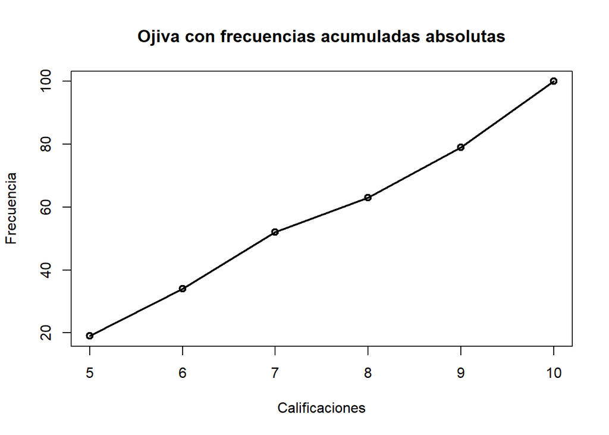

2. Obtener dos histogramas (absolutas y relativas) y dos ojivas (frecuencias acumuladas)

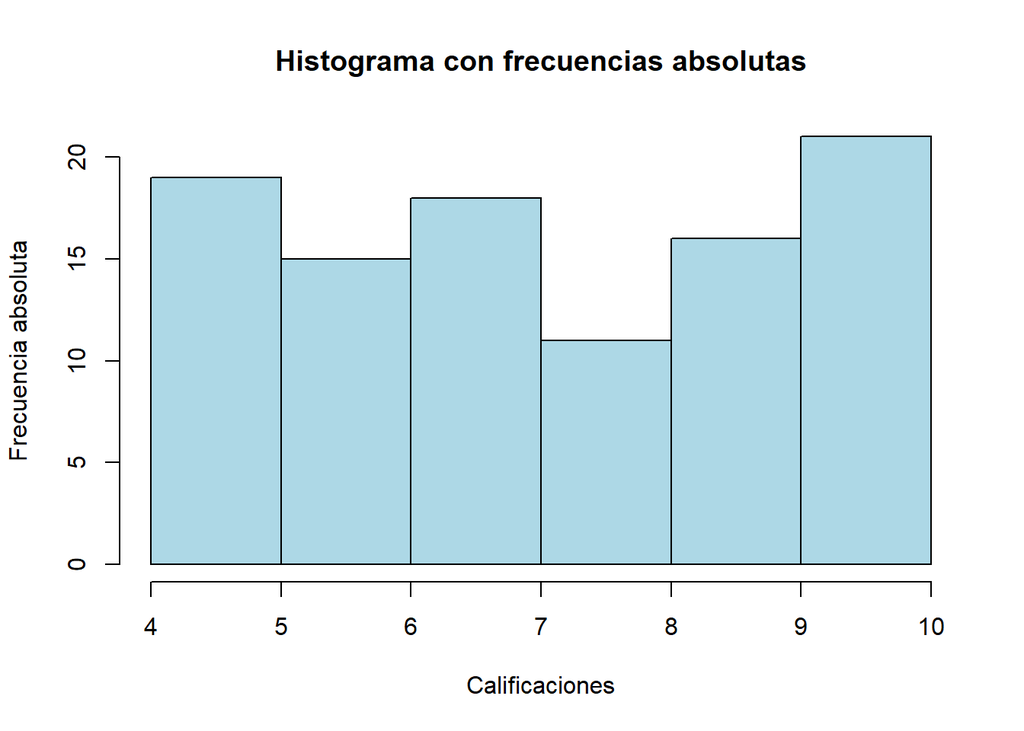

[figure not shown]

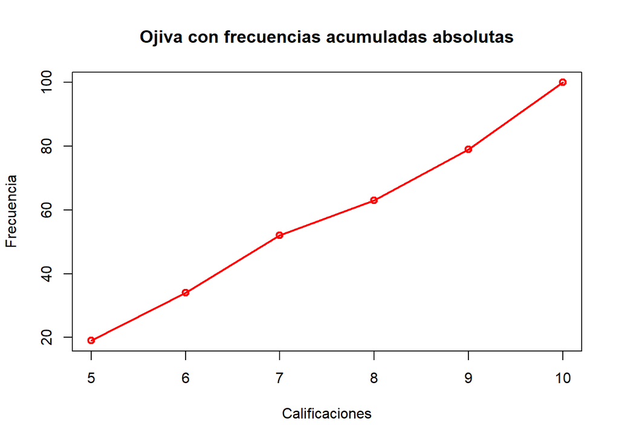

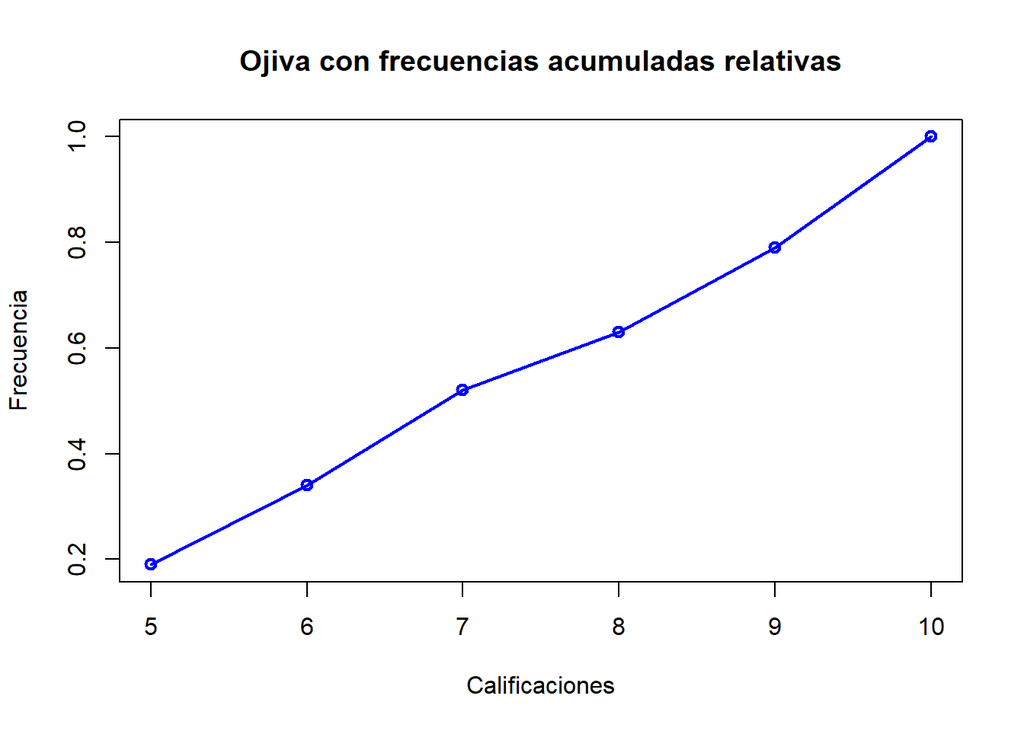

3. Observando la tabla de frecuencias, y los gráficos, ¿Qué se puede decir de este grupo de estudiantes?

Aunque hay más alumnos que tienen 10 de calificación (21) respecto a las demás calificaciones, la mayoría de ellos tiene 8 o menos de calificación. Por lo que este grupo tiene áreas de oportunidad para poder elevar la calificación de todos.